# Supplementary material for Consumers’ preferences for commons-based and open-source produce: A discrete choice experiment with directional information manipulations.

15/06/2023

This script analyses the data collected from the main survey of the paper “Consumers’ preferences for commons-based and open-source tomatoes: A discrete choice experiment”. It includes the second pilot, but not the first pilot. The first pilot cannot be used because attributes etc changed.

The script includes all relevant steps from preparation of raw data to final models. Readers can use the data and code.

The preregistration can be found here https://aspredicted.org/blind.php?x=K3X_S4Z

# 1 Prepare Data

**Prepare Data**

First, load packages and user written functions.

```r
rightseeds_live_pages <- read_excel("data/mainstudy/rightseeds_live_pages.xlsx")
```

```r
# read in all datasets and merge

dce_data <- bind_rows(read_excel("data/mainstudy/rightseeds_live_dce_gg.xlsx"), read_excel("data/mainstudy/rightseeds_live_dce_os.xlsx") ,.id = "gg") %>%  ## gg: 1= gg 2 = oc
  left_join(read_excel("data/mainstudy/rightseeds_live_covariates.xlsx"), by ="RID") #%>%
```

```
## left_join: added 140 columns (VERSION, STATUS, START, DURATION, RAND_A_slot1, …)
```

```
##            > rows only in x        0
```

```
##            > rows only in y  ( 9,367)
```

```
##            > matched rows     33,121
```

```
##            >                 ========
```

```
##            > rows total       33,121
```

```r
  #select(1:18, info_text)


dce_dict<- read_excel("data/mainstudy/rightseeds_live_dce_os.xlsx" , sheet = "dictionary")
cov_dict<- read_excel("data/mainstudy/rightseeds_live_covariates.xlsx" , sheet = "dictionary")
  # Merge with time stamp data to identify speeders

  database2 <-  dce_data%>%
   #filter(!is.na(pref1)) %>%
    filter(!is.na(q28), q8_16==4|q8_16 %in% c(4,6) ) %>%
left_join(rightseeds_live_pages, by="RID") %>%
  mutate(duration_lastp = PAGE_SUBMIT_30-PAGE_DISPLAY_30 ,
         duration_lastp_imputed= if_else(is.na(duration_lastp), mean(duration_lastp, na.rm=TRUE),duration_lastp ),
         DURATION_ALL= PAGE_DISPLAY_30+duration_lastp_imputed,
         threshold=1/3*mean(DURATION_ALL)) %>%
  filter(DURATION_ALL>threshold)  %>%
     mutate(Female=case_when(q20==2 ~ 1,   TRUE ~0) , Female_s =as.numeric(scale(Female, scale=FALSE)),
            Age_s = as.numeric(scale(q21, scale=FALSE)),
            HigherEdu=case_when(q26_new %in% c(1,2,3,8) ~ 0,   TRUE ~1) , HigherEdu_s =as.numeric(scale(HigherEdu, scale=FALSE)), # higher education as Meisterausbildung und höher
            Income=case_when(q28 ==7 ~ mean(q28,na.rm=TRUE),   TRUE ~q28) , Income_s =as.numeric(scale(Income, scale=FALSE)),
       across(matches("._x[4]$ " ) , ~ .x - 1 ) ,
                        oc = as.numeric(gg)-1 ,  # 0= commons 1 =open source
                        winter =as.numeric(jahreszeit)-1 ,  # 0=summer 1 = winter
           across(matches("._x1$") ,  ~ recode(  .x ,`1` = 0.99,`2` = 1.49  , `3` = 1.99 , `4` = 2.49 , `5` = 2.99 , `6` = 3.49 , `7` = 3.99 , `8` = 4.99 , .default =99999)) ,
           a1_EUBIO = a1_x2==2, a1_BIOVER = a1_x2==3 , a2_EUBIO = a2_x2==2, a2_BIOVER = a2_x2==3 ,
           a1_REG = a1_x3==1, a1_DE = a1_x3==2 , a1_ESP = a1_x3==3 , a1_MAR = a1_x3==4 ,a2_REG = a2_x3==1,  a2_DE = a2_x3==2 ,  a2_ESP = a2_x3==3 , a2_MAR = a2_x3==4
    )   %>%
    as.data.frame()
```

```
## filter: removed 4,510 rows (14%), 28,611 rows remaining
```

```
## left_join: added 62 columns (PAGE_DISPLAY_1, PAGE_SUBMIT_1, PAGE_DISPLAY_2, PAGE_SUBMIT_2, PAGE_DISPLAY_3, …)
```

```
##            > rows only in x        0
```

```
##            > rows only in y  ( 9,890)
```

```
##            > matched rows     28,611
```

```
##            >                 ========
```

```
##            > rows total       28,611
```

```
## mutate: new variable 'duration_lastp' (double) with 3,102 unique values and 2% NA
```

```
##         new variable 'duration_lastp_imputed' (double) with 3,102 unique values and 0% NA
```

```
##         new variable 'DURATION_ALL' (double) with 3,179 unique values and 0% NA
```

```
##         new variable 'threshold' (double) with one unique value and 0% NA
```

```
## filter: removed 288 rows (1%), 28,323 rows remaining
```

```
## mutate: changed 28,323 values (100%) of 'a1_x1' (0 new NA)
```

```
##         changed 28,323 values (100%) of 'a2_x1' (0 new NA)
```

```
##         new variable 'Female' (double) with 2 unique values and 0% NA
```

```
##         new variable 'Female_s' (double) with 2 unique values and 0% NA
```

```
##         new variable 'Age_s' (double) with 72 unique values and 0% NA
```

```
##         new variable 'HigherEdu' (double) with 2 unique values and 0% NA
```

```
##         new variable 'HigherEdu_s' (double) with 2 unique values and 0% NA
```

```
##         new variable 'Income' (double) with 7 unique values and 0% NA
```

```
##         new variable 'Income_s' (double) with 7 unique values and 0% NA
```

```
##         new variable 'oc' (double) with 2 unique values and 0% NA
```

```
##         new variable 'winter' (double) with 2 unique values and 0% NA
```

```
##         new variable 'a1_EUBIO' (logical) with 2 unique values and 0% NA
```

```
##         new variable 'a1_BIOVER' (logical) with 2 unique values and 0% NA
```

```
##         new variable 'a2_EUBIO' (logical) with 2 unique values and 0% NA
```

```
##         new variable 'a2_BIOVER' (logical) with 2 unique values and 0% NA
```

```
##         new variable 'a1_REG' (logical) with 2 unique values and 0% NA
```

```
##         new variable 'a1_DE' (logical) with 2 unique values and 0% NA
```

```
##         new variable 'a1_ESP' (logical) with 2 unique values and 0% NA
```

```
##         new variable 'a1_MAR' (logical) with 2 unique values and 0% NA
```

```
##         new variable 'a2_REG' (logical) with 2 unique values and 0% NA
```

```
##         new variable 'a2_DE' (logical) with 2 unique values and 0% NA
```

```
##         new variable 'a2_ESP' (logical) with 2 unique values and 0% NA
```

```
##         new variable 'a2_MAR' (logical) with 2 unique values and 0% NA
```

```r
 table(database2$gg)
```

```
##
##     1     2
## 14184 14139
```

```r
 length(unique(database2$RID))
```

```
## [1] 3147
```

# 2 Descriptive Analysis

We look at the frequencies of attribute levels and correlations between attributes. This should confirm that the design is balanced and orthogonal.

**Descriptive Analysis**

```r
table(database2$DESIGN_ROW)
```

```
##
##   1   2   3   4   5   6   7   8   9  10  11  12  13  14  15  16  17  18  19  20
## 401 401 401 401 401 401 401 401 401 396 396 396 396 396 396 396 396 396 396 396
##  21  22  23  24  25  26  27  28  29  30  31  32  33  34  35  36  37  38  39  40
## 396 396 396 396 396 396 396 396 396 396 396 396 396 396 396 396 393 393 393 393
##  41  42  43  44  45  46  47  48  49  50  51  52  53  54  55  56  57  58  59  60
## 393 393 393 393 393 388 388 388 388 388 388 388 388 388 386 386 386 386 386 386
##  61  62  63  64  65  66  67  68  69  70  71  72
## 386 386 386 391 391 391 391 391 391 391 391 391
```

```r
  ## For all respondents
  table(database2$a1_x1)
```

```
##
## 0.99 1.49 1.99 2.49 2.99 3.49 3.99 4.99
## 3526 3545 3550 3538 3548 3540 3535 3541
```

```r
  table(database2$a1_x2)
```

```
##
##    1    2    3
## 9446 9441 9436
```

```r
  table(database2$a1_x3)
```

```
##
##    1    2    3    4
## 7086 7078 7078 7081
```

```r
  table(database2$a1_x4)
```

```
##
##     1     2
## 14164 14159
```

```r
  #Only for the first respondents
  table(database2$a1_x1[unique(database2$DESIGN_ROW)], useNA = "always")
```

```
##
## 0.99 1.49 1.99 2.49 2.99 3.49 3.99 4.99 <NA>
##   12    6    6   11    9    8    8   12    0
```

```r
  table(database2$a1_x2[unique(database2$DESIGN_ROW)], useNA = "always")
```

```
##
##    1    2    3 <NA>
##   26   24   22    0
```

```r
  table(database2$a1_x3[unique(database2$DESIGN_ROW)], useNA = "always")
```

```
##
##    1    2    3    4 <NA>
##   21   16   16   19    0
```

```r
  table(database2$a1_x4[unique(database2$DESIGN_ROW)], useNA = "always")
```

```
##
##    1    2 <NA>
##   37   35    0
```

```r
  ## Over all observations
  cor(database2[, 6:15])
```

```
##               pref1        a1_x1         a1_x2         a1_x3         a1_x4
## pref1    1.00000000  0.268628262 -1.340165e-01  0.1927858678 -7.793627e-02
## a1_x1    0.26862826  1.000000000  1.026669e-03 -0.0031919608  6.410185e-03
## a1_x2   -0.13401649  0.001026669  1.000000e+00  0.0014693907 -7.633737e-08
## a1_x3    0.19278587 -0.003191961  1.469391e-03  1.0000000000  2.683426e-04
## a1_x4   -0.07793627  0.006410185 -7.633737e-08  0.0002683426  1.000000e+00
## a2_x1   -0.10452766  0.059144678 -4.037260e-02  0.0413930457 -5.031595e-02
## a2_x2    0.06502954 -0.076625475 -1.648308e-01 -0.2203929443 -8.431216e-02
## a2_x3    0.01140162  0.023358797 -2.142510e-01 -0.0055231272 -1.631386e-01
## a2_x4   -0.06687195 -0.189827555  6.747217e-02  0.0128335062 -8.523450e-02
## VERSION  0.01812262  0.002023917 -1.866432e-03 -0.0010221280 -7.619676e-04
##                a2_x1         a2_x2        a2_x3        a2_x4       VERSION
## pref1   -0.104527661  0.0650295398  0.011401615 -0.066871945  0.0181226230
## a1_x1    0.059144678 -0.0766254753  0.023358797 -0.189827555  0.0020239168
## a1_x2   -0.040372603 -0.1648308105 -0.214251016  0.067472171 -0.0018664320
## a1_x3    0.041393046 -0.2203929443 -0.005523127  0.012833506 -0.0010221280
## a1_x4   -0.050315952 -0.0843121599 -0.163138588 -0.085234499 -0.0007619676
## a2_x1    1.000000000 -0.0101995142 -0.109405811  0.045192489 -0.0033490439
## a2_x2   -0.010199514  1.0000000000 -0.021648228  0.016705635 -0.0007756457
## a2_x3   -0.109405811 -0.0216482282  1.000000000  0.002763816  0.0061504540
## a2_x4    0.045192489  0.0167056347  0.002763816  1.000000000 -0.0035664750
## VERSION -0.003349044 -0.0007756457  0.006150454 -0.003566475  1.0000000000
```

```r
  ## Only design
  cor(database2[(unique(database2$DESIGN_ROW)), 6:15])
```

```
##                pref1        a1_x1       a1_x2       a1_x3       a1_x4
## pref1    1.000000000 -0.003332704  0.10152512  0.25080014 -0.04136737
## a1_x1   -0.003332704  1.000000000 -0.05735713 -0.05469751  0.19088494
## a1_x2    0.101525124 -0.057357133  1.00000000 -0.11942520 -0.00189516
## a1_x3    0.250800140 -0.054697506 -0.11942520  1.00000000 -0.09632876
## a1_x4   -0.041367366  0.190884935 -0.00189516 -0.09632876  1.00000000
## a2_x1   -0.243759959  0.177453734 -0.13766485  0.01051251 -0.10683008
## a2_x2    0.040219476  0.156720287  0.02227837 -0.09523571 -0.01672177
## a2_x3   -0.057295380 -0.106575649 -0.41258166  0.03063510 -0.15585933
## a2_x4    0.177494424 -0.156663668  0.09866267  0.27241965  0.08194826
## VERSION           NA           NA          NA          NA          NA
##               a2_x1       a2_x2       a2_x3       a2_x4 VERSION
## pref1   -0.24375996  0.04021948 -0.05729538  0.17749442      NA
## a1_x1    0.17745373  0.15672029 -0.10657565 -0.15666367      NA
## a1_x2   -0.13766485  0.02227837 -0.41258166  0.09866267      NA
## a1_x3    0.01051251 -0.09523571  0.03063510  0.27241965      NA
## a1_x4   -0.10683008 -0.01672177 -0.15585933  0.08194826      NA
## a2_x1    1.00000000  0.03470494 -0.37439898 -0.06151973      NA
## a2_x2    0.03470494  1.00000000 -0.00968521  0.01817613      NA
## a2_x3   -0.37439898 -0.00968521  1.00000000 -0.01771635      NA
## a2_x4   -0.06151973  0.01817613 -0.01771635  1.00000000      NA
## VERSION          NA          NA          NA          NA       1
```

```r
  table(database2$pref1)
```

```
##
##     1     2     3
## 11995 12178  4150
```

```r
  #as probabilities

  table(database2$pref1)/length(database2$pref1)
```

```
##
##         1         2         3
## 0.4235074 0.4299686 0.1465240
```

We plot the choice probabilities conditional on the attribute level. It should confirm the direction and magnitute of our estimates.

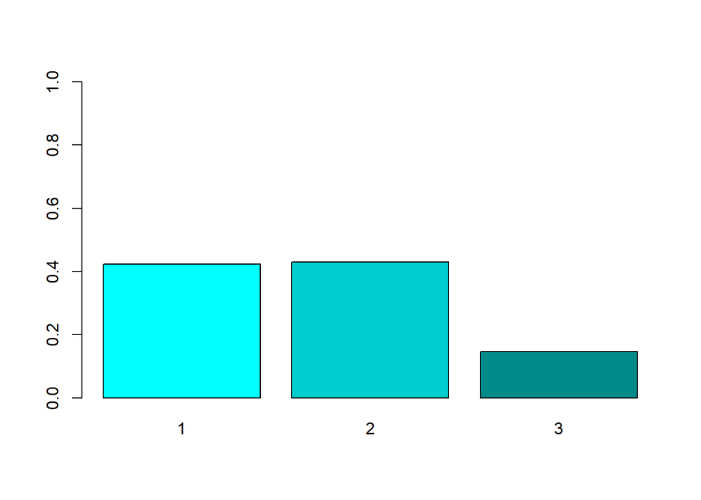

```r
  barplot(prop.table(table(database2$pref1)), ylim = c(0,1), col=c("cyan1", "cyan3", "darkcyan"))
```

```r
  aggregate(as.numeric(pref1)==1 ~ a1_x1 , data=database2 , mean)
```

```
##   a1_x1 as.numeric(pref1) == 1
## 1  0.99              0.5748724
## 2  1.49              0.6772920
## 3  1.99              0.5642254
## 4  2.49              0.3713963
## 5  2.99              0.4177001
## 6  3.49              0.2903955
## 7  3.99              0.2874116
## 8  4.99              0.2044620
```

```r
  aggregate(as.numeric(pref1)==2 ~ a2_x1 , data=database2 , mean)
```

```
##   a2_x1 as.numeric(pref1) == 2
## 1  0.99              0.5266122
## 2  1.49              0.6168914
## 3  1.99              0.7366337
## 4  2.49              0.3315355
## 5  2.99              0.4953297
## 6  3.49              0.2414669
## 7  3.99              0.1550847
## 8  4.99              0.3051471
```

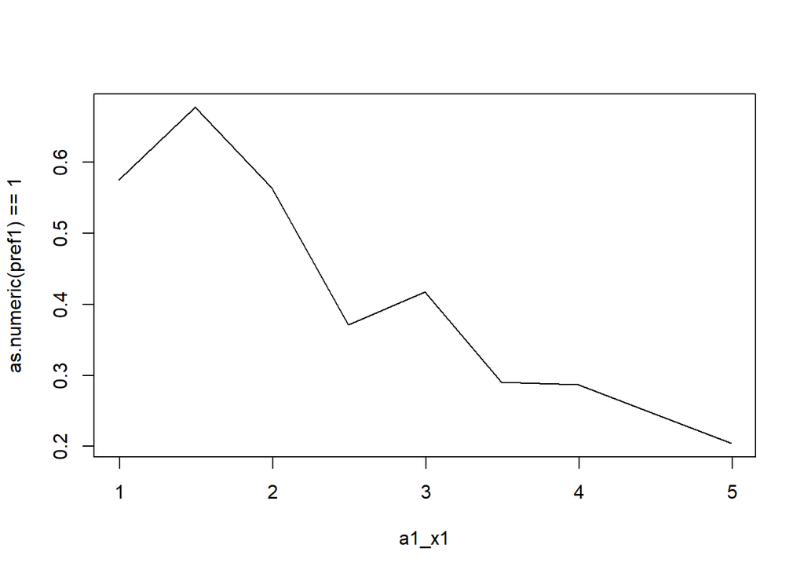

```r
  plot(aggregate(as.numeric(pref1)==1 ~ a1_x1 , data=database2 , mean), type="l")
```

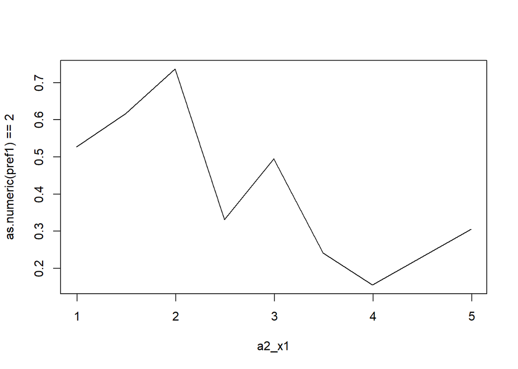

```r
  plot(aggregate(as.numeric(pref1)==2 ~ a2_x1 , data=database2 , mean), type="l")
```

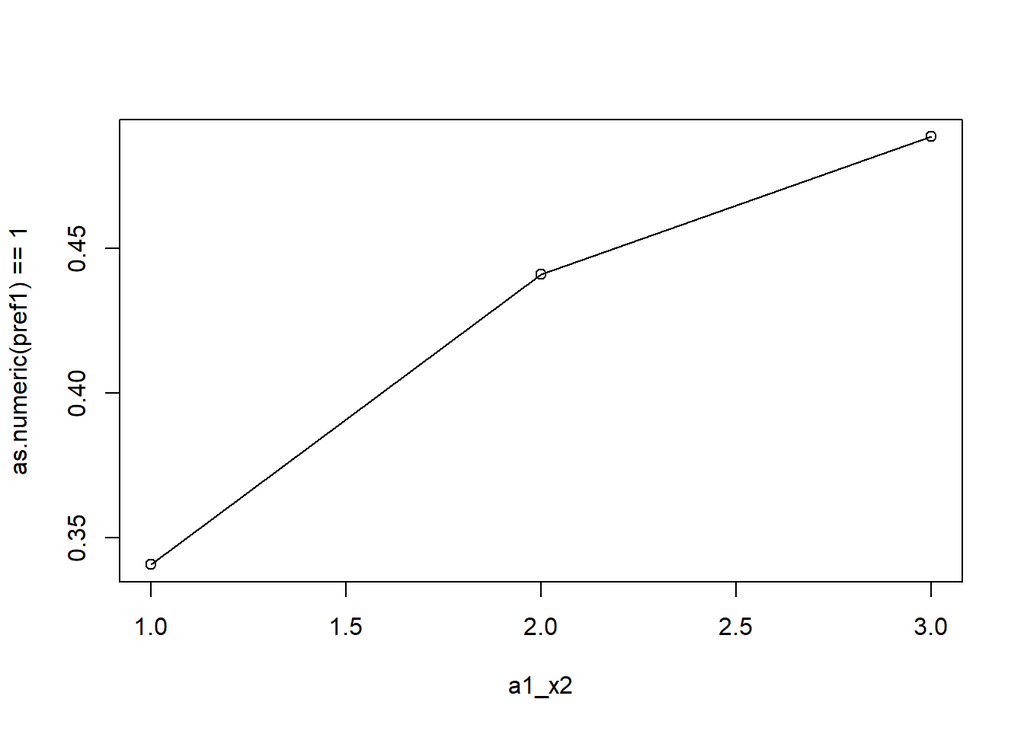

```r
  plot(aggregate(as.numeric(pref1)==1 ~ a1_x2 , data=database2 , mean), type="o")
```

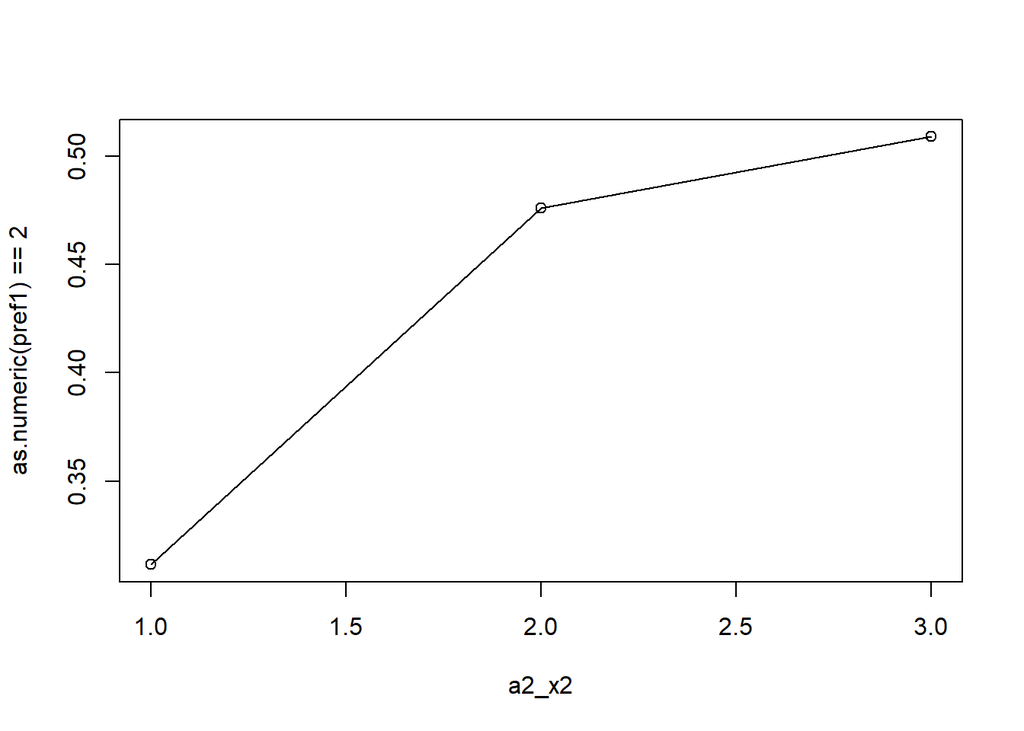

```r
  plot(aggregate(as.numeric(pref1)==2 ~ a2_x2 , data=database2 , mean), type="o")
```

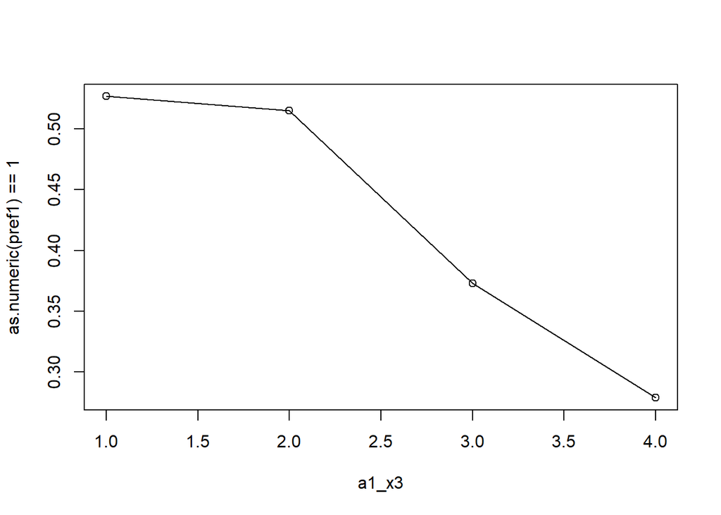

```r
  plot(aggregate(as.numeric(pref1)==1 ~ a1_x3 , data=database2 , mean), type="o")
```

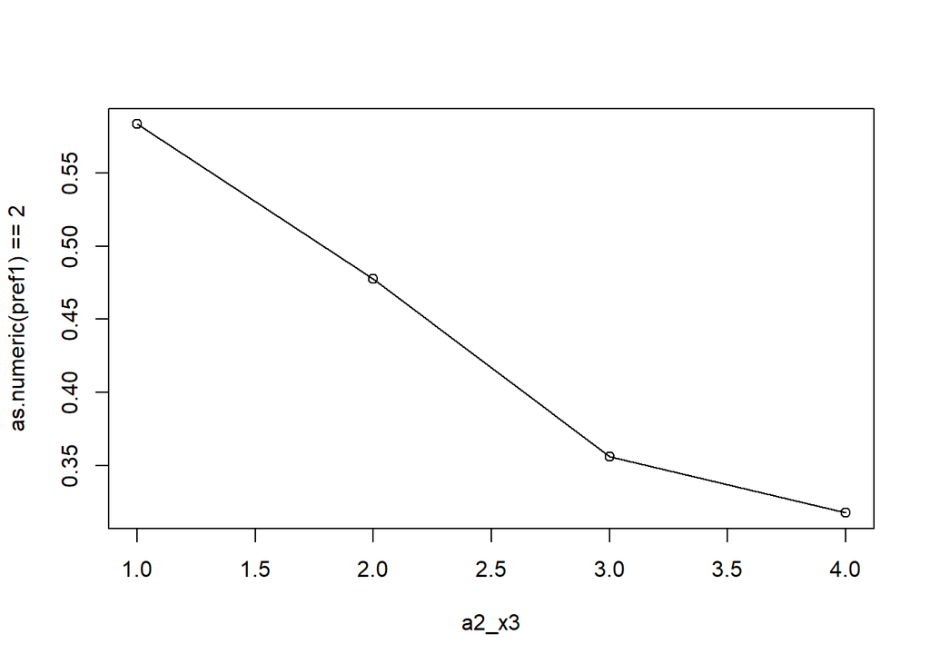

```r
  plot(aggregate(as.numeric(pref1)==2 ~ a2_x3 , data=database2 , mean), type="o")
```

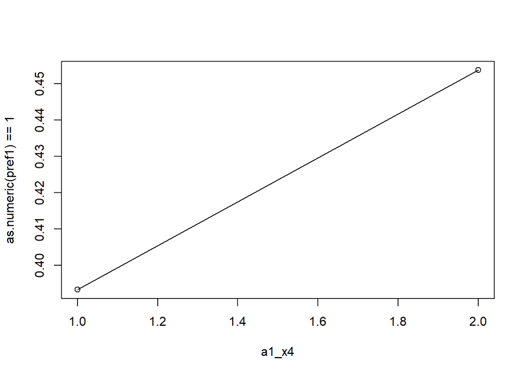

```r
  plot(aggregate(as.numeric(pref1)==1 ~ a1_x4 , data=database2 , mean), type="o")
```

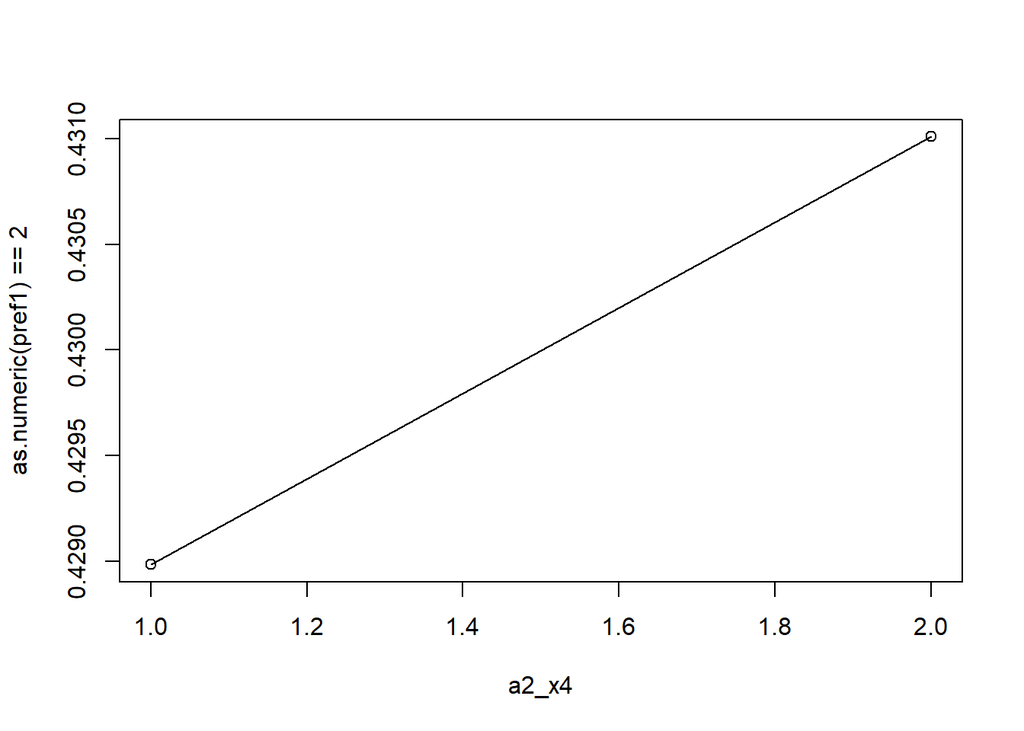

```r
  plot(aggregate(as.numeric(pref1)==2 ~ a2_x4 , data=database2 , mean), type="o")
```

The following table shows how often respondents have chosen which alternatives. For example the 151 in column Alt1 means that 151 respondents have chosen alternative 1 only once in all nine choice situations.

```r
ind_switch <- database2 %>%
  group_by(RID, pref1) %>%
  summarise(n = n()) %>%
  ungroup %>%
  group_by(n, pref1) %>%
  summarise(freq=n()) %>%
  arrange(pref1) %>%
  spread(pref1,freq,fill = 0) %>%
  rename(nchosen=n, Alt1 =2 , Alt2 = 3 , Optout = 4)
```

```
## group_by: 2 grouping variables (RID, pref1)
```

```
## summarise: now 7,663 rows and 3 columns, one group variable remaining (RID)
```

```
## ungroup: no grouping variables
```

```
## group_by: 2 grouping variables (n, pref1)
```

```
## summarise: now 27 rows and 3 columns, one group variable remaining (n)
```

```
## spread: reorganized (pref1, freq) into (1, 2, 3) [was 27x3, now 9x4]
```

```
## rename: renamed 4 variables (nchosen, Alt1, Alt2, Optout)
```

```r
kable(ind_switch) %>%  kable_classic_2(full_width = T)
```

| nchosen | Alt1 | Alt2 | Optout |
| --- | --- | --- | --- |
| 1 | 151 | 153 | 381 |
| 2 | 450 | 491 | 370 |
| 3 | 729 | 650 | 265 |
| 4 | 691 | 684 | 234 |
| 5 | 552 | 564 | 113 |
| 6 | 392 | 431 | 45 |
| 7 | 112 | 123 | 27 |
| 8 | 11 | 9 | 14 |
| 9 | 1 | 2 | 18 |

# 3 Logit Models

The following chunk will estimate the logit models. It is set to `eval = FALSE` as default because estimation takes long. To replicate the analysis, one has to run this chunk only once. The files will be saved as R objects in the local folder.

**Logit Models**

```r
source("scripts/clogitmodels.R")
source("scripts/mixlogitmodels.R")
source("scripts/mixedlogit_scriptinteractions.R")

delfiles <- dir(path="modeloutput/",  pattern=".csv" ,full.names = T)

file.remove(delfiles)
```

The following chunk is also set to `eval=FALSE`. It estimates Latent Class models with 2 to 6 classes.

```r
map(2:6, function(x) {n_classes <<- x
                       source("scripts/lcmodels/lc_body.R")
} )
```

The following chunks read in estimated models

```r
delfiles <- dir(path="modeloutput/",  pattern="OLD" ,full.names = T,recursive = TRUE)

file.remove(delfiles)






modelpath <-list.files(path = "modeloutput/WTPSpace/",pattern = "rds$" , full.names = TRUE, recursive = TRUE)
models_tex <- list()
models <- list()


for (name in modelpath) {

t <- readRDS(name)
#twtp <- wtp("b_cost",attr = names(t$estimate) , modelname=t) # only relevant if models are not estimated in WTP space

models[[t$apollo_control$modelName]] <-t
models_tex[[t$apollo_control$modelName]] <-quicktexregapollo(t)

}

rm(t, name, modelpath)
```

```r
modelpath <-list.files(path = "modeloutput/mixlogit_prefspace/",pattern = "rds$" , full.names = TRUE)

modelsWTP <- list()
modelsWTP_tex <- list()



for (name in modelpath) {

t <- readRDS(name)

if(any(t$apollo_draws$interNormDraws %in% "draws_cost")) mcost=TRUE else mcost=FALSE

print(mcost)

twtp <- wtp("mean_cost",attr = names(t$estimate) , modelname=t ,mediancost = mcost) # only relevant if models are not estimated in WTP space

models[[t$apollo_control$modelName]] <-t
models_tex[[t$apollo_control$modelName]] <-quicktexregapollo(t)
modelsWTP[[t$apollo_control$modelName]]<-twtp
modelsWTP_tex[[t$apollo_control$modelName]] <- quicktexregapollo(model=t,wtpest = twtp)

}

#rm(t,twtp, name, modelpath)
```

This chunk loads saved latent class models and prepares tables with coefficients and willingness to pay.

```r
delfiles <- dir(path="modeloutput/lclogit",  pattern="OLD" ,full.names = T)

file.remove(delfiles)

modelpath <-list.files(path = "modeloutput/lclogit/",pattern = "*.rds" , full.names = TRUE)
lcmodels_tex <- list()
lcmodels     <- list()
lcmodelsWTP  <- list()
lcmodelsWTP_tex <- list()

for (name in modelpath) {

  t <- readRDS(name)

  twtp <- wtp_lc(modelname=t)

  lcmodels[[t$apollo_control$modelName]]     <-t
  lcmodels_tex[[t$apollo_control$modelName]] <-quicktexregapollo(t)
  lcmodelsWTP[[t$apollo_control$modelName]]  <- twtp

 for (class in 1:(length(t$LL0)-1)) {

    cl <- twtp[[class]]
    clet <- intToUtf8(96+class)



 lcmodelsWTP_tex[[t$apollo_control$modelName]][[paste0("Class", class)]] <-  quicktexregapollo(t,cl)

}


}

rm(t,twtp, name, modelpath)
```

# 4 Appendix A: Individual Willingness to Pay Values

Based on the models presented in the main text, the following present individual (conditional) willingness to pay values.

**Appendix A: Individual Willingness to pay values**

```r
library(purrr)
library(ggpubr)
```

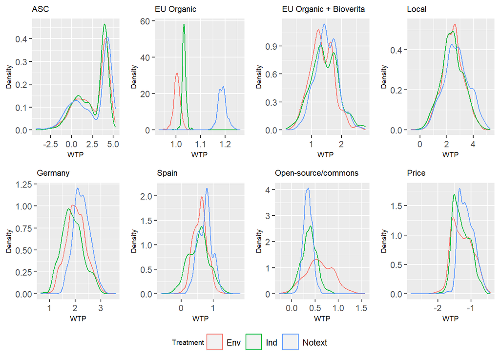

```r
# Read in individual WTP estimates
individualWTP_notext <- readRDS("modeloutput/Individual_wtp/individualWTP_notext.rds")
individualWTP_ind <- readRDS("modeloutput/Individual_wtp/individualWTP_ind.rds")
individualWTP_env <- readRDS("modeloutput/Individual_wtp/individualWTP_env.rds")

# names of the attributes
attribute_names <- c("ASC", "EU Organic", "EU Organic + Bioverita", "Local", "Germany", "Spain", "Open-source/commons", "Price")
names(individualWTP_env)<- attribute_names
names(individualWTP_ind)<- attribute_names
names(individualWTP_notext)<- attribute_names

# Define a function that takes a variable name as input and returns a ggplot object
plot_wtp <- function(var_name) {
  ggplot(data.frame(x = individualWTP_env[[var_name]]$post.mean), aes(x = x, col="Env")) +
    geom_density() +
    geom_density(data = data.frame(x = individualWTP_ind[[var_name]]$post.mean), aes(x = x, col="Ind")) +
    geom_density(data = data.frame(x = individualWTP_notext[[var_name]]$post.mean), aes(x = x, col="Notext")) +
    ggtitle(var_name) +
    xlab("WTP") +
    ylab("Density") +
    labs(col="Treatment") +
    theme(legend.position = c(0.15, 0.85),title = element_text(size=7))
}

# apply the function to each variable in individualWTP data frames
plot_list <- map(names(individualWTP_env), plot_wtp)


# plot densities
ggarrange(plotlist = plot_list, nrow = 2, ncol = 4, common.legend = T, legend = "bottom")
```

# 5 Appendix B: Models separated by Season

Respondents were randomly assigned into either a winter or a summer scenario. The following output shows two mixed logit models in WTP space separated by winter and summer samples.

**Appendix B: Models separated by season**

```r
library(tibble)
library(reshape2)
```

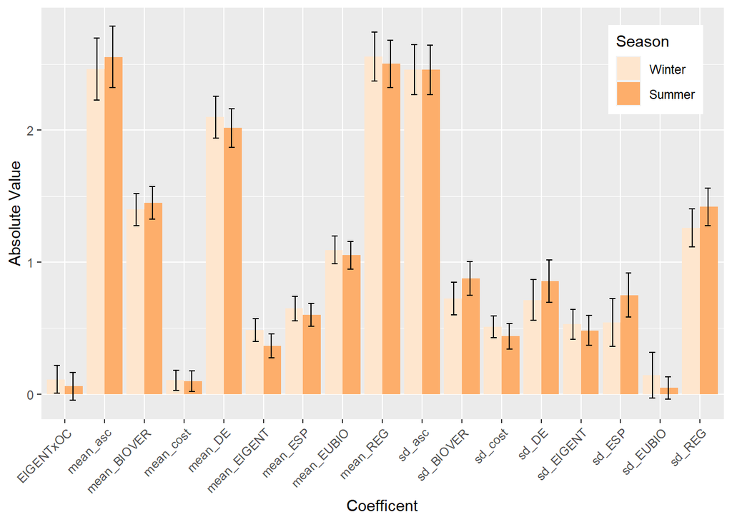

```r
mxl_season_compare <- as.data.frame(models$mixlog_season_winter$estimate)
mxl_season_compare[2] <- as.data.frame(models$mixlog_season_summer$estimate)

alpha = 0.1 # set confidence level

mxl_season_compare$margin_of_error_w <- qnorm(1-alpha/2)*models$mixlog_season_winter$robse
mxl_season_compare$margin_of_error_s <- qnorm(1-alpha/2)*models$mixlog_season_summer$robse

mxl_season_compare <- rownames_to_column(mxl_season_compare, "Coefficent")

colnames(mxl_season_compare) <- c("Coefficent", "Estimate_winter", "Estimate_summer", "Margin_of_error_winter",
                                "Margin_of_error_summer")


mxl_melt_season <- melt(mxl_season_compare[1:3], id = "Coefficent")
mxl_melt_season$ME <- mxl_season_compare$Margin_of_error_winter
mxl_melt_season$ME[18:34] <- mxl_season_compare$Margin_of_error_summer


ggplot(data=mxl_melt_season, aes(x=Coefficent, y=abs(value), fill=variable)) +
  geom_bar(stat="identity",  position='dodge', width = 0.9) +
  geom_errorbar(aes(x=Coefficent, ymin=abs(value)-ME, ymax=abs(value)+ME), width=0.3, position=position_dodge(0.8)) +
  ylab("Absolute Value") +
  scale_x_discrete(guide = guide_axis(angle = 45)) +
  scale_fill_brewer(palette = 7, labels = c("Winter", "Summer"), name="Season") +
  theme(legend.position = c(0.9, 0.85))
```

```r
mixmodelsWTP_tex <- models_tex[c("mixlog_season_winter", "mixlog_season_summer") ]

coef_names <- c("ASC: Mean", "ASC: Standard deviation", "EU Organic: Mean", "EU Organic: Standard deviation", "EU Organic + Bioverita: Mean", "EU Organic + Bioverita: Standard Deviation", "Local: Mean", "Local: Standard deviation", "Germany: Mean", "Germany: Standard deviation", "Spain: Mean", "Spain: Standard deviation", "Open-source/commons: Mean", "Open-source/commons: Standard deviation", "Price: Mean", "Price: Standard deviation", "Ownership x Open-source vs. commons")

htmlreg(l = mixmodelsWTP_tex  ,
        custom.model.names = c("Winter", "Summer") ,  caption = "Results for mixed logit model for the two different seasons" , single.row = T  , custom.coef.names = coef_names,
        custom.note = "***p < 0.001; **p < 0.01; *p < 0.05 Standard Errors in Brackets" , center = TRUE, doctype = FALSE)
```

Results for mixed logit model for the two different seasons

|  | Winter | Summer |
| --- | --- | --- |
| ASC: Mean | 2.46 (0.14)*** | 2.55 (0.14)*** |
| ASC: Standard deviation | 2.46 (0.12)*** | 2.46 (0.11)*** |
| EU Organic: Mean | 1.09 (0.06)*** | 1.05 (0.06)*** |
| EU Organic: Standard deviation | -0.14 (0.11) | -0.05 (0.05) |
| EU Organic + Bioverita: Mean | 1.40 (0.07)*** | 1.45 (0.08)*** |
| EU Organic + Bioverita: Standard Deviation | 0.72 (0.07)*** | 0.87 (0.08)*** |
| Local: Mean | 2.56 (0.11)*** | 2.50 (0.11)*** |
| Local: Standard deviation | 1.26 (0.09)*** | 1.42 (0.09)*** |
| Germany: Mean | 2.10 (0.10)*** | 2.02 (0.09)*** |
| Germany: Standard deviation | 0.71 (0.09)*** | 0.86 (0.10)*** |
| Spain: Mean | 0.65 (0.06)*** | 0.60 (0.05)*** |
| Spain: Standard deviation | 0.54 (0.11)*** | 0.75 (0.10)*** |
| Open-source/commons: Mean | 0.49 (0.05)*** | 0.37 (0.05)*** |
| Open-source/commons: Standard deviation | 0.53 (0.07)*** | 0.48 (0.07)*** |
| Price: Mean | 0.10 (0.05)* | 0.10 (0.05)* |
| Price: Standard deviation | 0.51 (0.05)*** | 0.44 (0.06)*** |
| Ownership x Open-source vs. commons | -0.11 (0.06)* | 0.06 (0.06) |
| No Observations | 14112 | 14211 |
| No Respondents | 1568 | 1579 |
| Log Likelihood (Null) | -15503.62 | -15612.38 |
| Log Likelihood (Converged) | -10055.62 | -10214.02 |

**p < 0.001;** p < 0.01; p < 0.05 Standard Errors in Brackets

# 6 Appendix C: Models separated by Tomato Type

The following shows mixed logit models in WTP space separated by tomato type. Before starting with the choice experiment, respondents could choose whether they purchase cherry tomatoes or flesh tomatos.

**Appendix C: Models separated by Tomato Type**

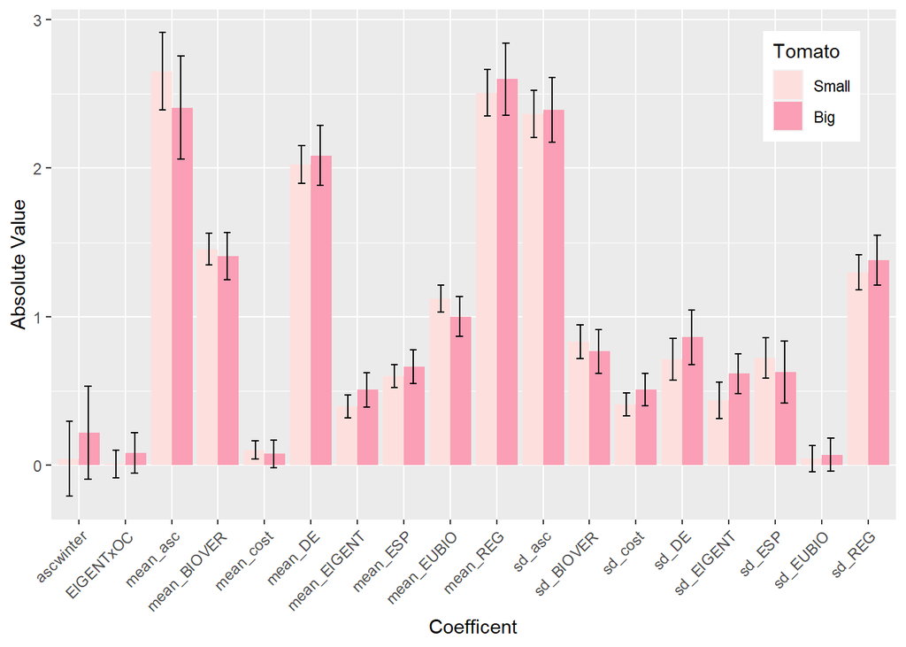

```r
mxl_tomato_compare <- as.data.frame(models$mixlog_small_tomato$estimate)
mxl_tomato_compare[2] <- as.data.frame(models$mixlog_big_tomato$estimate)

alpha = 0.1 # set confidence level

mxl_tomato_compare$margin_of_error_w <- qnorm(1-alpha/2)*models$mixlog_small_tomato$robse
mxl_tomato_compare$margin_of_error_s <- qnorm(1-alpha/2)*models$mixlog_big_tomato$robse

mxl_tomato_compare <- rownames_to_column(mxl_tomato_compare, "Coefficent")

colnames(mxl_tomato_compare) <- c("Coefficent", "Estimate_small", "Estimate_big", "Margin_of_error_small",
                                "Margin_of_error_big")


mxl_melt_tomato <- melt(mxl_tomato_compare[1:3], id = "Coefficent")
mxl_melt_tomato$ME <- mxl_tomato_compare$Margin_of_error_small
mxl_melt_tomato$ME[19:36] <- mxl_tomato_compare$Margin_of_error_big


ggplot(data=mxl_melt_tomato, aes(x=Coefficent, y=abs(value), fill=variable)) +
  geom_bar(stat="identity",  position='dodge', width = 0.9) +
  geom_errorbar(aes(x=Coefficent, ymin=abs(value)-ME, ymax=abs(value)+ME), width=0.3, position=position_dodge(0.8)) +
  ylab("Absolute Value") +
  scale_x_discrete(guide = guide_axis(angle = 45)) +
  scale_fill_brewer(palette = 13, labels = c("Small", "Big"), name="Tomato") +
  theme(legend.position = c(0.9, 0.85))
```

```r
mixmodelsWTP_tex <- models_tex[c("mixlog_small_tomato", "mixlog_big_tomato") ]

coef_names <- c("ASC: Mean", "ASC: Standard deviation", "EU Organic: Mean", "EU Organic: Standard deviation", "EU Organic + Bioverita: Mean", "EU Organic + Bioverita: Standard Deviation", "Local: Mean", "Local: Standard deviation", "Germany: Mean", "Germany: Standard deviation", "Spain: Mean", "Spain: Standard deviation", "Open-source/commons: Mean", "Open-source/commons: Standard deviation", "Price: Mean", "Price: Standard deviation", "ASC x Winter", "Ownership x Open-source vs. commons")

htmlreg(l = mixmodelsWTP_tex  ,
        custom.model.names = c("Small Tomato", "Big Tomato") ,  caption = "Results for mixed logit model for the two different tomato types" , single.row = T  , custom.coef.names = coef_names,
        custom.note = "***p < 0.001; **p < 0.01; *p < 0.05 Standard Errors in Brackets" , center = TRUE, doctype = FALSE)
```

Results for mixed logit model for the two different tomato types

|  | Small Tomato | Big Tomato |
| --- | --- | --- |
| ASC: Mean | 2.65 (0.16)*** | 2.41 (0.21)*** |
| ASC: Standard deviation | 2.37 (0.10)*** | 2.39 (0.13)*** |
| EU Organic: Mean | 1.12 (0.06)*** | 1.00 (0.08)*** |
| EU Organic: Standard deviation | -0.04 (0.05) | 0.07 (0.07) |
| EU Organic + Bioverita: Mean | 1.45 (0.07)*** | 1.41 (0.10)*** |
| EU Organic + Bioverita: Standard Deviation | 0.83 (0.07)*** | 0.76 (0.09)*** |
| Local: Mean | 2.51 (0.09)*** | 2.60 (0.15)*** |
| Local: Standard deviation | 1.30 (0.07)*** | 1.38 (0.10)*** |
| Germany: Mean | 2.03 (0.08)*** | 2.09 (0.12)*** |
| Germany: Standard deviation | 0.71 (0.09)*** | 0.86 (0.11)*** |
| Spain: Mean | 0.60 (0.05)*** | 0.66 (0.07)*** |
| Spain: Standard deviation | 0.72 (0.08)*** | 0.62 (0.13)*** |
| Open-source/commons: Mean | 0.39 (0.05)*** | 0.51 (0.07)*** |
| Open-source/commons: Standard deviation | -0.43 (0.07)*** | 0.61 (0.08)*** |
| Price: Mean | 0.10 (0.04)** | 0.07 (0.06) |
| Price: Standard deviation | 0.41 (0.05)*** | 0.51 (0.07)*** |
| ASC x Winter | -0.04 (0.15) | -0.22 (0.19) |
| Ownership x Open-source vs. commons | 0.01 (0.06) | -0.08 (0.08) |
| No Observations | 17901 | 9504 |
| No Respondents | 1989 | 1056 |
| Log Likelihood (Null) | -19666.26 | -10441.21 |
| Log Likelihood (Converged) | -12576.22 | -6978.20 |

**p < 0.001;** p < 0.01; p < 0.05 Standard Errors in Brackets